# examples_0202

When solving the equation below with standard algebraic methods, two possible solutions are found.

$$5+\sqrt{5x+94}=-x+3$$

Let $x_1$ and $x_2$ represent the two possible solutions, such that $x_1<x_2$. Find both possible solutions and determine whether each is valid or extraneous.

- $x_1=$
- $x_1$ is solution.
- $x_2=$
- $x_2$ is solution.

$$5+\sqrt{5x+94}=-x+3$$

Subtract 5 from both sides of the equation.
$$\sqrt{5x+94}=-x-2$$
Square both sides of the equation. Remember, you'll need to FOIL the right side.
$$5x+94=x^2+4x+4$$
Subtract $( 5x+94 )$ from both sides.
$$0=x^2-x-90$$
From here, you can either factor or use quadratic formula. It is easy enough to factor this one.
$$0=(x+9)(x-10)$$
Use the zero-product property to identify the possible solutions are $x_1=-9$ and $x_2=10$. Notice we correctly ordered them such that $x_1<x_2$. Now we check which solution is valid by plugging both into the original equation.

Start with possible solution $x=-9$
$$5+\sqrt{5(-9)+94}\stackrel{?}{=}-(-9)+3$$

$$5+\sqrt{-45+94}\stackrel{?}{=}9+3$$

$$5+\sqrt{49}\stackrel{?}{=}12$$

$$5+7\stackrel{?}{=}12$$

$$12=12$$
So we see $x=-9$ is a valid solution.

Now check possible solution $x=10$
$$5+\sqrt{5(10)+94}\stackrel{?}{=}-(10)+3$$

$$5+\sqrt{50+94}\stackrel{?}{=}-10+3$$

$$5+\sqrt{144}\stackrel{?}{=}-7$$

$$5+12\stackrel{?}{=}-7$$

$$17\ne -7$$
So we see $x=10$ is an extraneous solution.

When solving the equation below with standard algebraic methods, two possible solutions are found.

$$-6-\sqrt{-9x-23}=-x-7$$

Let $x_1$ and $x_2$ represent the two possible solutions, such that $x_1<x_2$. Find both possible solutions and determine whether each is valid or extraneous.

- $x_1=$
- $x_1$ is solution.
- $x_2=$
- $x_2$ is solution.

$$-6-\sqrt{-9x-23}=-x-7$$

Add 6 to both sides of the equation.
$$-\sqrt{-9x-23}=-x-1$$
Multiply both sides by $-1$.
$$\sqrt{-9x-23}=x+1$$
Square both sides of the equation. Remember, you'll need to FOIL the right side.
$$-9x-23=x^2+2x+1$$
Subtract $( -9x-23 )$ from both sides.
$$0=x^2+11x+24$$
From here, you can either factor or use quadratic formula. It is easy enough to factor this one.
$$0=(x+8)(x+3)$$
Use the zero-product property to identify the possible solutions are $x_1=-8$ and $x_2=-3$. Notice we correctly ordered them such that $x_1<x_2$. Now we check which solution is valid by plugging both into the original equation.

Start with possible solution $x=-8$
$$-6-\sqrt{-9(-8)-23}\stackrel{?}{=}-(-8)-7$$

$$-6-\sqrt{72-23}\stackrel{?}{=}8-7$$

$$-6-\sqrt{49}\stackrel{?}{=}1$$

$$-6-7\stackrel{?}{=}1$$

$$-13\ne 1$$
So we see $x=-8$ is an extraneous solution.

Now check possible solution $x=-3$
$$-6-\sqrt{-9(-3)-23}\stackrel{?}{=}-(-3)-7$$

$$-6-\sqrt{27-23}\stackrel{?}{=}3-7$$

$$-6-\sqrt{4}\stackrel{?}{=}-4$$

$$-6-2\stackrel{?}{=}-4$$

$$-8\ne -4$$
So we see $x=-3$ is an extraneous solution.

When solving the equation below with standard algebraic methods, two possible solutions are found.

$$7+\sqrt{-5x+34}=x-1$$

Let $x_1$ and $x_2$ represent the two possible solutions, such that $x_1<x_2$. Find both possible solutions and determine whether each is valid or extraneous.

- $x_1=$
- $x_1$ is solution.
- $x_2=$
- $x_2$ is solution.

$$7+\sqrt{-5x+34}=x-1$$

Subtract 7 from both sides of the equation.
$$\sqrt{-5x+34}=x-8$$
Square both sides of the equation. Remember, you'll need to FOIL the right side.
$$-5x+34=x^2-16x+64$$
Subtract $( -5x+34 )$ from both sides.
$$0=x^2-11x+30$$
From here, you can either factor or use quadratic formula. It is easy enough to factor this one.
$$0=(x-5)(x-6)$$
Use the zero-product property to identify the possible solutions are $x_1=5$ and $x_2=6$. Notice we correctly ordered them such that $x_1<x_2$. Now we check which solution is valid by plugging both into the original equation.

Start with possible solution $x=5$
$$7+\sqrt{-5(5)+34}\stackrel{?}{=}(5)-1$$

$$7+\sqrt{-25+34}\stackrel{?}{=}5-1$$

$$7+\sqrt{9}\stackrel{?}{=}4$$

$$7+3\stackrel{?}{=}4$$

$$10\ne 4$$
So we see $x=5$ is an extraneous solution.

Now check possible solution $x=6$
$$7+\sqrt{-5(6)+34}\stackrel{?}{=}(6)-1$$

$$7+\sqrt{-30+34}\stackrel{?}{=}6-1$$

$$7+\sqrt{4}\stackrel{?}{=}5$$

$$7+2\stackrel{?}{=}5$$

$$9\ne 5$$
So we see $x=6$ is an extraneous solution.

When solving the equation below with standard algebraic methods, two possible solutions are found.

$$9+\sqrt{6x+33}=x+10$$

Let $x_1$ and $x_2$ represent the two possible solutions, such that $x_1<x_2$. Find both possible solutions and determine whether each is valid or extraneous.

- $x_1=$
- $x_1$ is solution.
- $x_2=$
- $x_2$ is solution.

$$9+\sqrt{6x+33}=x+10$$

Subtract 9 from both sides of the equation.
$$\sqrt{6x+33}=x+1$$
Square both sides of the equation. Remember, you'll need to FOIL the right side.
$$6x+33=x^2+2x+1$$
Subtract $( 6x+33 )$ from both sides.
$$0=x^2-4x-32$$
From here, you can either factor or use quadratic formula. It is easy enough to factor this one.
$$0=(x+4)(x-8)$$
Use the zero-product property to identify the possible solutions are $x_1=-4$ and $x_2=8$. Notice we correctly ordered them such that $x_1<x_2$. Now we check which solution is valid by plugging both into the original equation.

Start with possible solution $x=-4$
$$9+\sqrt{6(-4)+33}\stackrel{?}{=}(-4)+10$$

$$9+\sqrt{-24+33}\stackrel{?}{=}-4+10$$

$$9+\sqrt{9}\stackrel{?}{=}6$$

$$9+3\stackrel{?}{=}6$$

$$12\ne 6$$
So we see $x=-4$ is an extraneous solution.

Now check possible solution $x=8$
$$9+\sqrt{6(8)+33}\stackrel{?}{=}(8)+10$$

$$9+\sqrt{48+33}\stackrel{?}{=}8+10$$

$$9+\sqrt{81}\stackrel{?}{=}18$$

$$9+9\stackrel{?}{=}18$$

$$18=18$$
So we see $x=8$ is a valid solution.

When solving the equation below with standard algebraic methods, two possible solutions are found.

$$-2+\sqrt{7x+44}=x+6$$

Let $x_1$ and $x_2$ represent the two possible solutions, such that $x_1<x_2$. Find both possible solutions and determine whether each is valid or extraneous.

- $x_1=$
- $x_1$ is solution.
- $x_2=$
- $x_2$ is solution.

$$-2+\sqrt{7x+44}=x+6$$

Add 2 to both sides of the equation.
$$\sqrt{7x+44}=x+8$$
Square both sides of the equation. Remember, you'll need to FOIL the right side.
$$7x+44=x^2+16x+64$$
Subtract $( 7x+44 )$ from both sides.
$$0=x^2+9x+20$$
From here, you can either factor or use quadratic formula. It is easy enough to factor this one.
$$0=(x+5)(x+4)$$
Use the zero-product property to identify the possible solutions are $x_1=-5$ and $x_2=-4$. Notice we correctly ordered them such that $x_1<x_2$. Now we check which solution is valid by plugging both into the original equation.

Start with possible solution $x=-5$
$$-2+\sqrt{7(-5)+44}\stackrel{?}{=}(-5)+6$$

$$-2+\sqrt{-35+44}\stackrel{?}{=}-5+6$$

$$-2+\sqrt{9}\stackrel{?}{=}1$$

$$-2+3\stackrel{?}{=}1$$

$$1=1$$
So we see $x=-5$ is a valid solution.

Now check possible solution $x=-4$
$$-2+\sqrt{7(-4)+44}\stackrel{?}{=}(-4)+6$$

$$-2+\sqrt{-28+44}\stackrel{?}{=}-4+6$$

$$-2+\sqrt{16}\stackrel{?}{=}2$$

$$-2+4\stackrel{?}{=}2$$

$$2=2$$
So we see $x=-4$ is a valid solution.

When solving the equation below with standard algebraic methods, two possible solutions are found.

$$1+\sqrt{3x+13}=x+4$$

Let $x_1$ and $x_2$ represent the two possible solutions, such that $x_1<x_2$. Find both possible solutions and determine whether each is valid or extraneous.

- $x_1=$
- $x_1$ is solution.
- $x_2=$
- $x_2$ is solution.

$$1+\sqrt{3x+13}=x+4$$

Subtract 1 from both sides of the equation.
$$\sqrt{3x+13}=x+3$$
Square both sides of the equation. Remember, you'll need to FOIL the right side.
$$3x+13=x^2+6x+9$$
Subtract $( 3x+13 )$ from both sides.
$$0=x^2+3x-4$$
From here, you can either factor or use quadratic formula. It is easy enough to factor this one.
$$0=(x+4)(x-1)$$
Use the zero-product property to identify the possible solutions are $x_1=-4$ and $x_2=1$. Notice we correctly ordered them such that $x_1<x_2$. Now we check which solution is valid by plugging both into the original equation.

Start with possible solution $x=-4$
$$1+\sqrt{3(-4)+13}\stackrel{?}{=}(-4)+4$$

$$1+\sqrt{-12+13}\stackrel{?}{=}-4+4$$

$$1+\sqrt{1}\stackrel{?}{=}0$$

$$1+1\stackrel{?}{=}0$$

$$2\ne 0$$
So we see $x=-4$ is an extraneous solution.

Now check possible solution $x=1$
$$1+\sqrt{3(1)+13}\stackrel{?}{=}(1)+4$$

$$1+\sqrt{3+13}\stackrel{?}{=}1+4$$

$$1+\sqrt{16}\stackrel{?}{=}5$$

$$1+4\stackrel{?}{=}5$$

$$5=5$$
So we see $x=1$ is a valid solution.

When solving the equation below with standard algebraic methods, two possible solutions are found.

$$-4+\sqrt{-9x+31}=x-5$$

Let $x_1$ and $x_2$ represent the two possible solutions, such that $x_1<x_2$. Find both possible solutions and determine whether each is valid or extraneous.

- $x_1=$
- $x_1$ is solution.
- $x_2=$
- $x_2$ is solution.

$$-4+\sqrt{-9x+31}=x-5$$

Add 4 to both sides of the equation.
$$\sqrt{-9x+31}=x-1$$
Square both sides of the equation. Remember, you'll need to FOIL the right side.
$$-9x+31=x^2-2x+1$$
Subtract $( -9x+31 )$ from both sides.
$$0=x^2+7x-30$$
From here, you can either factor or use quadratic formula. It is easy enough to factor this one.
$$0=(x+10)(x-3)$$
Use the zero-product property to identify the possible solutions are $x_1=-10$ and $x_2=3$. Notice we correctly ordered them such that $x_1<x_2$. Now we check which solution is valid by plugging both into the original equation.

Start with possible solution $x=-10$
$$-4+\sqrt{-9(-10)+31}\stackrel{?}{=}(-10)-5$$

$$-4+\sqrt{90+31}\stackrel{?}{=}-10-5$$

$$-4+\sqrt{121}\stackrel{?}{=}-15$$

$$-4+11\stackrel{?}{=}-15$$

$$7\ne -15$$
So we see $x=-10$ is an extraneous solution.

Now check possible solution $x=3$
$$-4+\sqrt{-9(3)+31}\stackrel{?}{=}(3)-5$$

$$-4+\sqrt{-27+31}\stackrel{?}{=}3-5$$

$$-4+\sqrt{4}\stackrel{?}{=}-2$$

$$-4+2\stackrel{?}{=}-2$$

$$-2=-2$$
So we see $x=3$ is a valid solution.

When solving the equation below with standard algebraic methods, two possible solutions are found.

$$1+\sqrt{3x-14}=x-3$$

Let $x_1$ and $x_2$ represent the two possible solutions, such that $x_1<x_2$. Find both possible solutions and determine whether each is valid or extraneous.

- $x_1=$
- $x_1$ is solution.
- $x_2=$
- $x_2$ is solution.

$$1+\sqrt{3x-14}=x-3$$

Subtract 1 from both sides of the equation.
$$\sqrt{3x-14}=x-4$$
Square both sides of the equation. Remember, you'll need to FOIL the right side.
$$3x-14=x^2-8x+16$$
Subtract $( 3x-14 )$ from both sides.
$$0=x^2-11x+30$$
From here, you can either factor or use quadratic formula. It is easy enough to factor this one.
$$0=(x-5)(x-6)$$
Use the zero-product property to identify the possible solutions are $x_1=5$ and $x_2=6$. Notice we correctly ordered them such that $x_1<x_2$. Now we check which solution is valid by plugging both into the original equation.

Start with possible solution $x=5$
$$1+\sqrt{3(5)-14}\stackrel{?}{=}(5)-3$$

$$1+\sqrt{15-14}\stackrel{?}{=}5-3$$

$$1+\sqrt{1}\stackrel{?}{=}2$$

$$1+1\stackrel{?}{=}2$$

$$2=2$$
So we see $x=5$ is a valid solution.

Now check possible solution $x=6$
$$1+\sqrt{3(6)-14}\stackrel{?}{=}(6)-3$$

$$1+\sqrt{18-14}\stackrel{?}{=}6-3$$

$$1+\sqrt{4}\stackrel{?}{=}3$$

$$1+2\stackrel{?}{=}3$$

$$3=3$$
So we see $x=6$ is a valid solution.

When solving the equation below with standard algebraic methods, two possible solutions are found.

$$-6-\sqrt{-9x+10}=-x-4$$

Let $x_1$ and $x_2$ represent the two possible solutions, such that $x_1<x_2$. Find both possible solutions and determine whether each is valid or extraneous.

- $x_1=$
- $x_1$ is solution.
- $x_2=$
- $x_2$ is solution.

$$-6-\sqrt{-9x+10}=-x-4$$

Add 6 to both sides of the equation.
$$-\sqrt{-9x+10}=-x+2$$
Multiply both sides by $-1$.
$$\sqrt{-9x+10}=x-2$$
Square both sides of the equation. Remember, you'll need to FOIL the right side.
$$-9x+10=x^2-4x+4$$
Subtract $( -9x+10 )$ from both sides.
$$0=x^2+5x-6$$
From here, you can either factor or use quadratic formula. It is easy enough to factor this one.
$$0=(x+6)(x-1)$$
Use the zero-product property to identify the possible solutions are $x_1=-6$ and $x_2=1$. Notice we correctly ordered them such that $x_1<x_2$. Now we check which solution is valid by plugging both into the original equation.

Start with possible solution $x=-6$
$$-6-\sqrt{-9(-6)+10}\stackrel{?}{=}-(-6)-4$$

$$-6-\sqrt{54+10}\stackrel{?}{=}6-4$$

$$-6-\sqrt{64}\stackrel{?}{=}2$$

$$-6-8\stackrel{?}{=}2$$

$$-14\ne 2$$
So we see $x=-6$ is an extraneous solution.

Now check possible solution $x=1$
$$-6-\sqrt{-9(1)+10}\stackrel{?}{=}-(1)-4$$

$$-6-\sqrt{-9+10}\stackrel{?}{=}-1-4$$

$$-6-\sqrt{1}\stackrel{?}{=}-5$$

$$-6-1\stackrel{?}{=}-5$$

$$-7\ne -5$$
So we see $x=1$ is an extraneous solution.

When solving the equation below with standard algebraic methods, two possible solutions are found.

$$5-\sqrt{-7x+50}=-x+13$$

Let $x_1$ and $x_2$ represent the two possible solutions, such that $x_1<x_2$. Find both possible solutions and determine whether each is valid or extraneous.

- $x_1=$
- $x_1$ is solution.
- $x_2=$
- $x_2$ is solution.

$$5-\sqrt{-7x+50}=-x+13$$

Subtract 5 from both sides of the equation.
$$-\sqrt{-7x+50}=-x+8$$
Multiply both sides by $-1$.
$$\sqrt{-7x+50}=x-8$$
Square both sides of the equation. Remember, you'll need to FOIL the right side.
$$-7x+50=x^2-16x+64$$
Subtract $( -7x+50 )$ from both sides.
$$0=x^2-9x+14$$
From here, you can either factor or use quadratic formula. It is easy enough to factor this one.
$$0=(x-2)(x-7)$$
Use the zero-product property to identify the possible solutions are $x_1=2$ and $x_2=7$. Notice we correctly ordered them such that $x_1<x_2$. Now we check which solution is valid by plugging both into the original equation.

Start with possible solution $x=2$
$$5-\sqrt{-7(2)+50}\stackrel{?}{=}-(2)+13$$

$$5-\sqrt{-14+50}\stackrel{?}{=}-2+13$$

$$5-\sqrt{36}\stackrel{?}{=}11$$

$$5-6\stackrel{?}{=}11$$

$$-1\ne 11$$
So we see $x=2$ is an extraneous solution.

Now check possible solution $x=7$
$$5-\sqrt{-7(7)+50}\stackrel{?}{=}-(7)+13$$

$$5-\sqrt{-49+50}\stackrel{?}{=}-7+13$$

$$5-\sqrt{1}\stackrel{?}{=}6$$

$$5-1\stackrel{?}{=}6$$

$$4\ne 6$$
So we see $x=7$ is an extraneous solution.

The equation below has one extraneous solution and one valid solution.

$$3+2\sqrt{2x+43}~=~2x+11$$

We can find both using [Desmos](https://www.desmos.com/calculator). To find the valid solution, find the intersection of the following two curves:

$$f(x)=3+2\sqrt{2x+43}$$
$$L(x)=2x+11$$

You should see half a parabola facing sideways and a line. Click where the two curves cross. The $x$ value is the valid solution.

The extraneous solution also has a geometric interpretation! We need to complete the parabola by plotting the following curve:

$$g(x)=3-2\sqrt{2x+43}$$

You should see the line crosses this second half of the parabola. Click on the intersection. The $x$ value is the extraneous solution.

- Valid:
- Extraneous:

The valid solution is $x=3$, and the extraneous solution is $x=-9$. Your Desmos graph should look somewhat similar to the graph below:

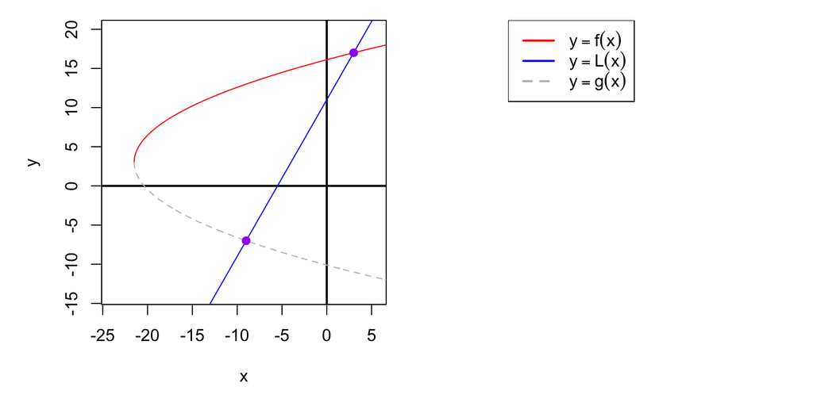

The equation below has one extraneous solution and one valid solution.

$$2+2\sqrt{5x+61}~=~2x+12$$

We can find both using [Desmos](https://www.desmos.com/calculator). To find the valid solution, find the intersection of the following two curves:

$$f(x)=2+2\sqrt{5x+61}$$
$$L(x)=2x+12$$

You should see half a parabola facing sideways and a line. Click where the two curves cross. The $x$ value is the valid solution.

The extraneous solution also has a geometric interpretation! We need to complete the parabola by plotting the following curve:

$$g(x)=2-2\sqrt{5x+61}$$

You should see the line crosses this second half of the parabola. Click on the intersection. The $x$ value is the extraneous solution.

- Valid:
- Extraneous:

The valid solution is $x=4$, and the extraneous solution is $x=-9$. Your Desmos graph should look somewhat similar to the graph below:

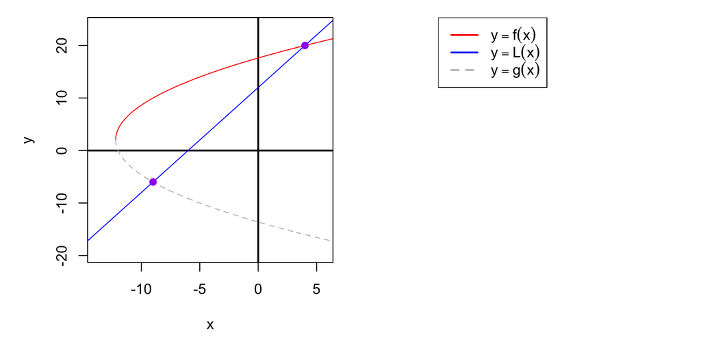

The equation below has one extraneous solution and one valid solution.

$$-8+2\sqrt{4x+16}~=~-2x-10$$

We can find both using [Desmos](https://www.desmos.com/calculator). To find the valid solution, find the intersection of the following two curves:

$$f(x)=-8+2\sqrt{4x+16}$$
$$L(x)=-2x-10$$

You should see half a parabola facing sideways and a line. Click where the two curves cross. The $x$ value is the valid solution.

The extraneous solution also has a geometric interpretation! We need to complete the parabola by plotting the following curve:

$$g(x)=-8-2\sqrt{4x+16}$$

You should see the line crosses this second half of the parabola. Click on the intersection. The $x$ value is the extraneous solution.

- Valid:
- Extraneous:

The valid solution is $x=-3$, and the extraneous solution is $x=5$. Your Desmos graph should look somewhat similar to the graph below:

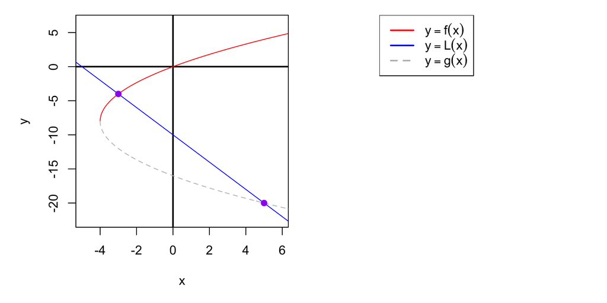

The equation below has one extraneous solution and one valid solution.

$$2-2\sqrt{5x+11}~=~2x+4$$

We can find both using [Desmos](https://www.desmos.com/calculator). To find the valid solution, find the intersection of the following two curves:

$$f(x)=2-2\sqrt{5x+11}$$
$$L(x)=2x+4$$

You should see half a parabola facing sideways and a line. Click where the two curves cross. The $x$ value is the valid solution.

The extraneous solution also has a geometric interpretation! We need to complete the parabola by plotting the following curve:

$$g(x)=2+2\sqrt{5x+11}$$

You should see the line crosses this second half of the parabola. Click on the intersection. The $x$ value is the extraneous solution.

- Valid:
- Extraneous:

The valid solution is $x=-2$, and the extraneous solution is $x=5$. Your Desmos graph should look somewhat similar to the graph below:

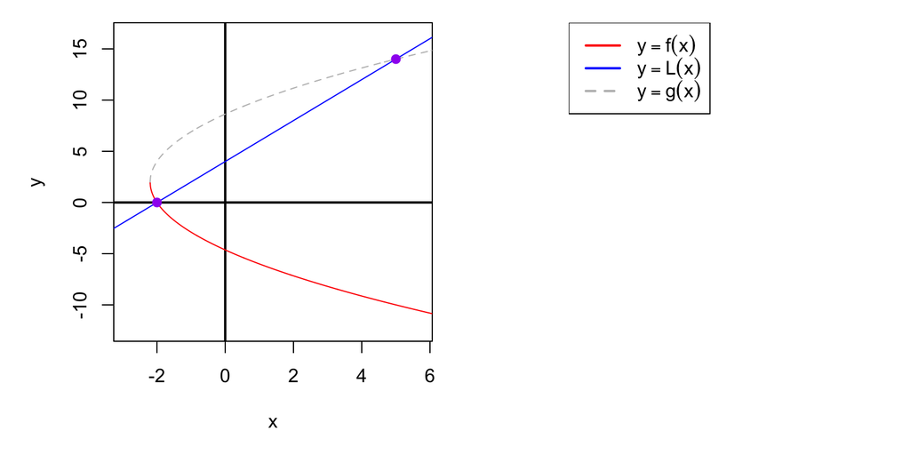

The equation below has one extraneous solution and one valid solution.

$$-2+2\sqrt{2x+22}~=~-2x-16$$

We can find both using [Desmos](https://www.desmos.com/calculator). To find the valid solution, find the intersection of the following two curves:

$$f(x)=-2+2\sqrt{2x+22}$$
$$L(x)=-2x-16$$

You should see half a parabola facing sideways and a line. Click where the two curves cross. The $x$ value is the valid solution.

The extraneous solution also has a geometric interpretation! We need to complete the parabola by plotting the following curve:

$$g(x)=-2-2\sqrt{2x+22}$$

You should see the line crosses this second half of the parabola. Click on the intersection. The $x$ value is the extraneous solution.

- Valid:
- Extraneous:

The valid solution is $x=-9$, and the extraneous solution is $x=-3$. Your Desmos graph should look somewhat similar to the graph below:

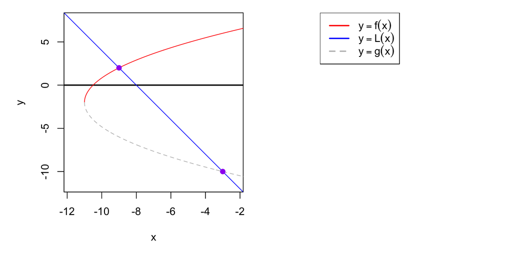

The equation below has one extraneous solution and one valid solution.

$$-7-2\sqrt{-4x-3}~=~2x-3$$

We can find both using [Desmos](https://www.desmos.com/calculator). To find the valid solution, find the intersection of the following two curves:

$$f(x)=-7-2\sqrt{-4x-3}$$
$$L(x)=2x-3$$

You should see half a parabola facing sideways and a line. Click where the two curves cross. The $x$ value is the valid solution.

The extraneous solution also has a geometric interpretation! We need to complete the parabola by plotting the following curve:

$$g(x)=-7+2\sqrt{-4x-3}$$

You should see the line crosses this second half of the parabola. Click on the intersection. The $x$ value is the extraneous solution.

- Valid:
- Extraneous:

The valid solution is $x=-7$, and the extraneous solution is $x=-1$. Your Desmos graph should look somewhat similar to the graph below:

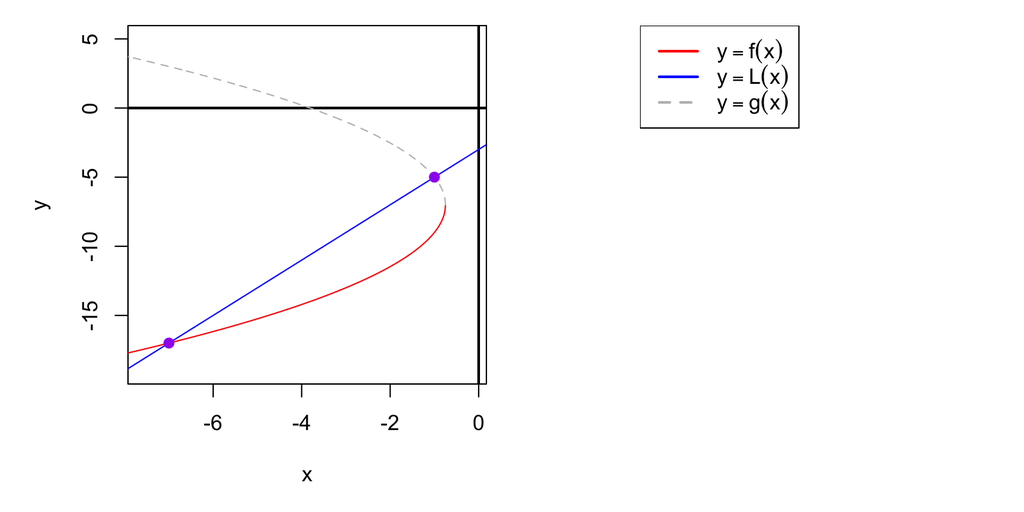

The equation below has one extraneous solution and one valid solution.

$$5-2\sqrt{2x+34}~=~2x+15$$

We can find both using [Desmos](https://www.desmos.com/calculator). To find the valid solution, find the intersection of the following two curves:

$$f(x)=5-2\sqrt{2x+34}$$
$$L(x)=2x+15$$

You should see half a parabola facing sideways and a line. Click where the two curves cross. The $x$ value is the valid solution.

The extraneous solution also has a geometric interpretation! We need to complete the parabola by plotting the following curve:

$$g(x)=5+2\sqrt{2x+34}$$

You should see the line crosses this second half of the parabola. Click on the intersection. The $x$ value is the extraneous solution.

- Valid:
- Extraneous:

The valid solution is $x=-9$, and the extraneous solution is $x=1$. Your Desmos graph should look somewhat similar to the graph below:

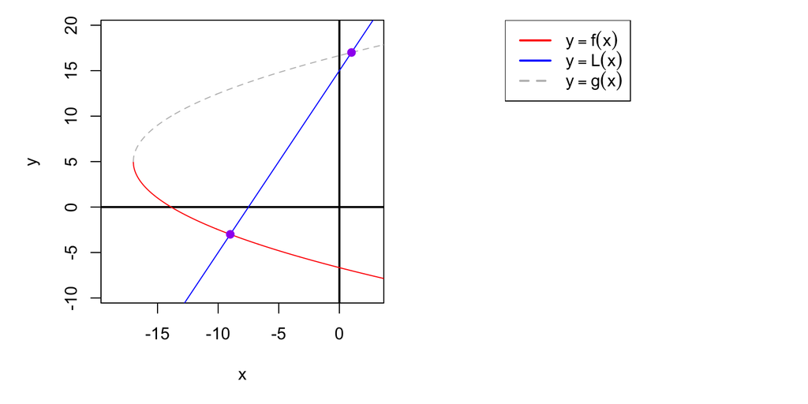

The equation below has one extraneous solution and one valid solution.

$$-2-2\sqrt{7x+57}~=~-2x-16$$

We can find both using [Desmos](https://www.desmos.com/calculator). To find the valid solution, find the intersection of the following two curves:

$$f(x)=-2-2\sqrt{7x+57}$$
$$L(x)=-2x-16$$

You should see half a parabola facing sideways and a line. Click where the two curves cross. The $x$ value is the valid solution.

The extraneous solution also has a geometric interpretation! We need to complete the parabola by plotting the following curve:

$$g(x)=-2+2\sqrt{7x+57}$$

You should see the line crosses this second half of the parabola. Click on the intersection. The $x$ value is the extraneous solution.

- Valid:
- Extraneous:

The valid solution is $x=1$, and the extraneous solution is $x=-8$. Your Desmos graph should look somewhat similar to the graph below:

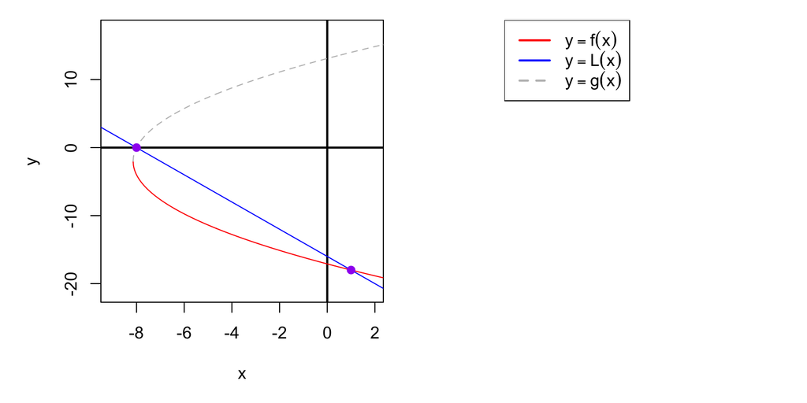

The equation below has one extraneous solution and one valid solution.

$$4-2\sqrt{-2x-1}~=~2x+8$$

We can find both using [Desmos](https://www.desmos.com/calculator). To find the valid solution, find the intersection of the following two curves:

$$f(x)=4-2\sqrt{-2x-1}$$
$$L(x)=2x+8$$

You should see half a parabola facing sideways and a line. Click where the two curves cross. The $x$ value is the valid solution.

The extraneous solution also has a geometric interpretation! We need to complete the parabola by plotting the following curve:

$$g(x)=4+2\sqrt{-2x-1}$$

You should see the line crosses this second half of the parabola. Click on the intersection. The $x$ value is the extraneous solution.

- Valid:
- Extraneous:

The valid solution is $x=-5$, and the extraneous solution is $x=-1$. Your Desmos graph should look somewhat similar to the graph below:

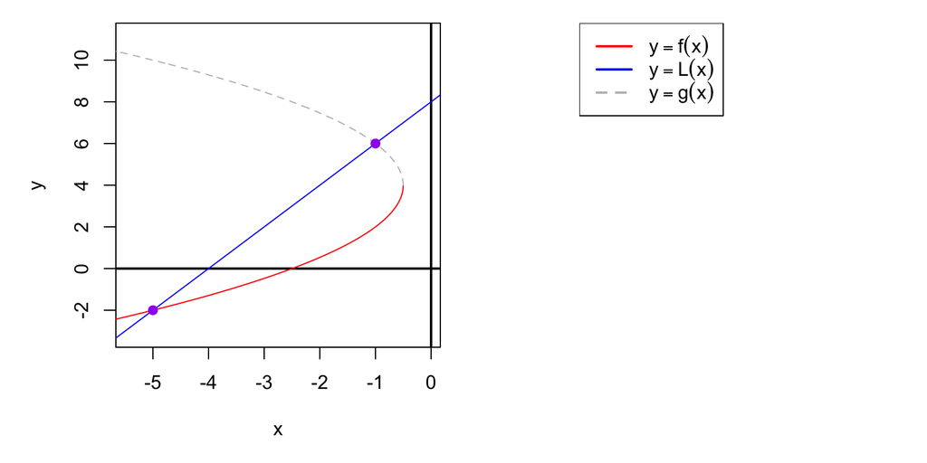

The equation below has one extraneous solution and one valid solution.

$$5-2\sqrt{4x+37}~=~2x+21$$

We can find both using [Desmos](https://www.desmos.com/calculator). To find the valid solution, find the intersection of the following two curves:

$$f(x)=5-2\sqrt{4x+37}$$
$$L(x)=2x+21$$

You should see half a parabola facing sideways and a line. Click where the two curves cross. The $x$ value is the valid solution.

The extraneous solution also has a geometric interpretation! We need to complete the parabola by plotting the following curve:

$$g(x)=5+2\sqrt{4x+37}$$

You should see the line crosses this second half of the parabola. Click on the intersection. The $x$ value is the extraneous solution.

- Valid:
- Extraneous:

The valid solution is $x=-9$, and the extraneous solution is $x=-3$. Your Desmos graph should look somewhat similar to the graph below:

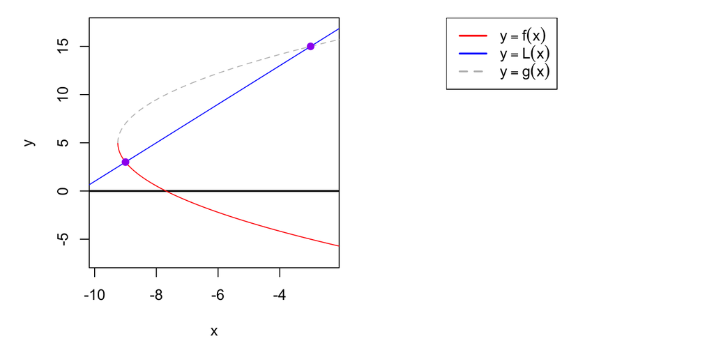

A transformed square-root function, $f(x)$, and line, $L(x)$, are parameterized and graphed below.

$$f(x)=a\sqrt{n(x-h)}+k$$

$$L(x)=mx+b$$
The parameters:
$$\begin{aligned}
a &= \text{vertical flip and stretch} \\
n &= \text{horizontal flip and stretch} \\
h &= \text{horizontal translation} \\
k &= \text{vertical translation} \\
m &= \text{slope} \\
b &= \text{y-intercept}
\end{aligned}$$

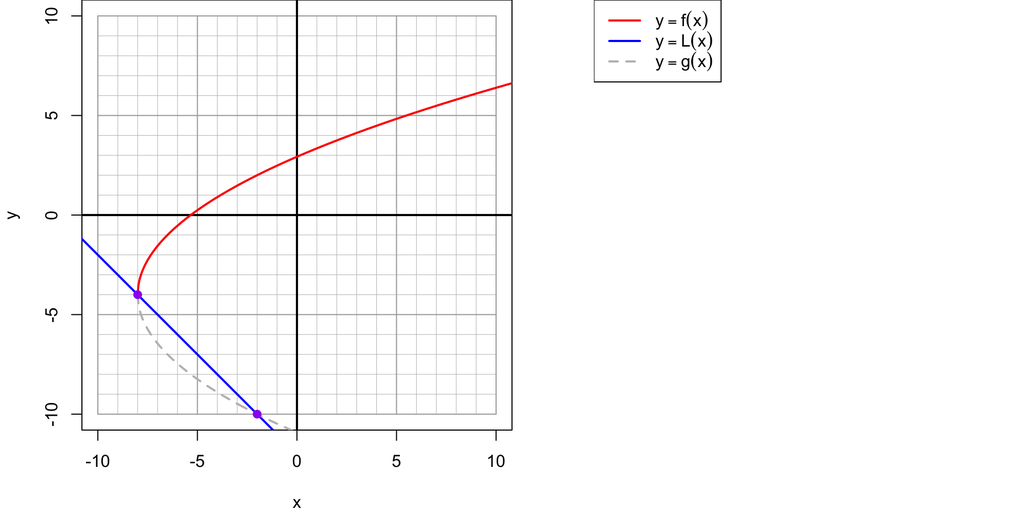

Notice, another transformed square-root function, $g(x)$, is also graphed above. It represents the other half of the parabola.

$$g(x)=-a\sqrt{n(x-h)}+k$$

Now, consider algebraically solving for values of $x_{i}$ that satisfy the equation $f(x_i)=L(x_i)$. Let $x_1$ and $x_2$ represent the two possible solutions such that $x_1<x_2$. Find both possible solutions (by inspecting the graph) and determine whether each is valid or extraneous.

- $x_1=$
- $x_1$ is solution.
- $x_2=$
- $x_2$ is solution.

Just read off the two $x$ values of the two purple points. The point further left is at point $(x_1,L(x_1))$ and the point further right is at point $(x_2,L(x_2))$. That way $x_1<x_2$, as required in the problem statement.

If the purple dot is on the red $y=f(x)$ curve, then the possible solution is a valid solution. If the purple dot is on the dashed-grey $y=g(x)$ curve, then the possible solution is extraneous. Lastly, if the purple dot is at the vertex of the parabol, then the solution is also valid.

So, in this case:

$$\begin{aligned}
x_1 &= -8 \\
x_1 &\text{ is a valid solution} \\
x_2 &= -2 \\
x_2 &\text{ is an extraneous solution}
\end{aligned}$$

A transformed square-root function, $f(x)$, and line, $L(x)$, are parameterized and graphed below.

$$f(x)=a\sqrt{n(x-h)}+k$$

$$L(x)=mx+b$$
The parameters:
$$\begin{aligned}
a &= \text{vertical flip and stretch} \\
n &= \text{horizontal flip and stretch} \\
h &= \text{horizontal translation} \\
k &= \text{vertical translation} \\
m &= \text{slope} \\
b &= \text{y-intercept}
\end{aligned}$$

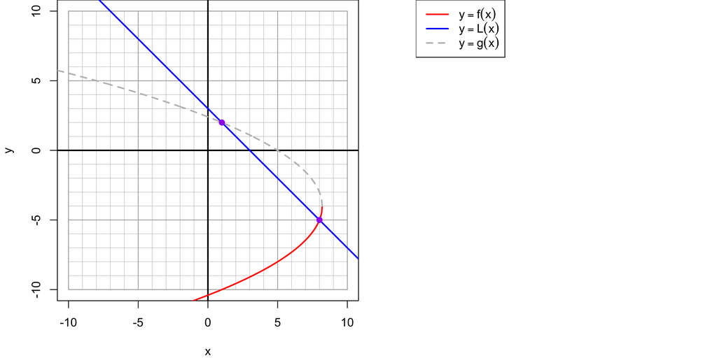

Notice, another transformed square-root function, $g(x)$, is also graphed above. It represents the other half of the parabola.

$$g(x)=-a\sqrt{n(x-h)}+k$$

Now, consider algebraically solving for values of $x_{i}$ that satisfy the equation $f(x_i)=L(x_i)$. Let $x_1$ and $x_2$ represent the two possible solutions such that $x_1<x_2$. Find both possible solutions (by inspecting the graph) and determine whether each is valid or extraneous.

- $x_1=$
- $x_1$ is solution.
- $x_2=$
- $x_2$ is solution.

Just read off the two $x$ values of the two purple points. The point further left is at point $(x_1,L(x_1))$ and the point further right is at point $(x_2,L(x_2))$. That way $x_1<x_2$, as required in the problem statement.

If the purple dot is on the red $y=f(x)$ curve, then the possible solution is a valid solution. If the purple dot is on the dashed-grey $y=g(x)$ curve, then the possible solution is extraneous. Lastly, if the purple dot is at the vertex of the parabol, then the solution is also valid.

So, in this case:

$$\begin{aligned}
x_1 &= 1 \\
x_1 &\text{ is an extraneous solution} \\
x_2 &= 8 \\
x_2 &\text{ is a valid solution}
\end{aligned}$$

A transformed square-root function, $f(x)$, and line, $L(x)$, are parameterized and graphed below.

$$f(x)=a\sqrt{n(x-h)}+k$$

$$L(x)=mx+b$$
The parameters:
$$\begin{aligned}
a &= \text{vertical flip and stretch} \\
n &= \text{horizontal flip and stretch} \\
h &= \text{horizontal translation} \\
k &= \text{vertical translation} \\
m &= \text{slope} \\
b &= \text{y-intercept}
\end{aligned}$$

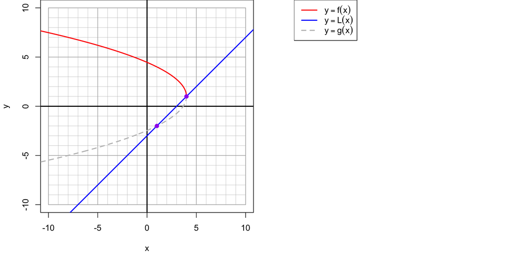

Notice, another transformed square-root function, $g(x)$, is also graphed above. It represents the other half of the parabola.

$$g(x)=-a\sqrt{n(x-h)}+k$$

Now, consider algebraically solving for values of $x_{i}$ that satisfy the equation $f(x_i)=L(x_i)$. Let $x_1$ and $x_2$ represent the two possible solutions such that $x_1<x_2$. Find both possible solutions (by inspecting the graph) and determine whether each is valid or extraneous.

- $x_1=$
- $x_1$ is solution.
- $x_2=$
- $x_2$ is solution.

Just read off the two $x$ values of the two purple points. The point further left is at point $(x_1,L(x_1))$ and the point further right is at point $(x_2,L(x_2))$. That way $x_1<x_2$, as required in the problem statement.

If the purple dot is on the red $y=f(x)$ curve, then the possible solution is a valid solution. If the purple dot is on the dashed-grey $y=g(x)$ curve, then the possible solution is extraneous. Lastly, if the purple dot is at the vertex of the parabol, then the solution is also valid.

So, in this case:

$$\begin{aligned}
x_1 &= 1 \\
x_1 &\text{ is an extraneous solution} \\
x_2 &= 4 \\
x_2 &\text{ is a valid solution}
\end{aligned}$$

A transformed square-root function, $f(x)$, and line, $L(x)$, are parameterized and graphed below.

$$f(x)=a\sqrt{n(x-h)}+k$$

$$L(x)=mx+b$$
The parameters:
$$\begin{aligned}
a &= \text{vertical flip and stretch} \\
n &= \text{horizontal flip and stretch} \\
h &= \text{horizontal translation} \\
k &= \text{vertical translation} \\
m &= \text{slope} \\
b &= \text{y-intercept}
\end{aligned}$$

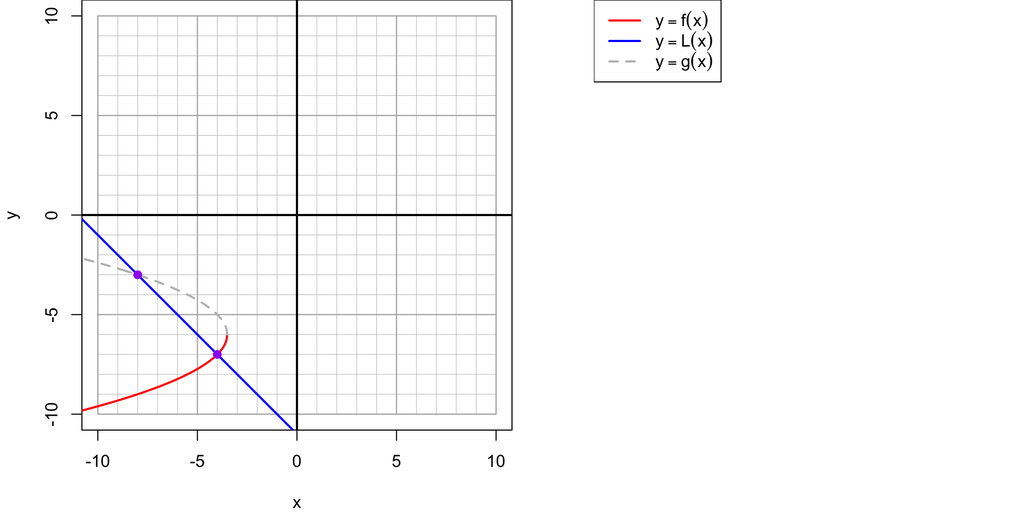

Notice, another transformed square-root function, $g(x)$, is also graphed above. It represents the other half of the parabola.

$$g(x)=-a\sqrt{n(x-h)}+k$$

Now, consider algebraically solving for values of $x_{i}$ that satisfy the equation $f(x_i)=L(x_i)$. Let $x_1$ and $x_2$ represent the two possible solutions such that $x_1<x_2$. Find both possible solutions (by inspecting the graph) and determine whether each is valid or extraneous.

- $x_1=$
- $x_1$ is solution.
- $x_2=$
- $x_2$ is solution.

Just read off the two $x$ values of the two purple points. The point further left is at point $(x_1,L(x_1))$ and the point further right is at point $(x_2,L(x_2))$. That way $x_1<x_2$, as required in the problem statement.

If the purple dot is on the red $y=f(x)$ curve, then the possible solution is a valid solution. If the purple dot is on the dashed-grey $y=g(x)$ curve, then the possible solution is extraneous. Lastly, if the purple dot is at the vertex of the parabol, then the solution is also valid.

So, in this case:

$$\begin{aligned}
x_1 &= -8 \\
x_1 &\text{ is an extraneous solution} \\
x_2 &= -4 \\
x_2 &\text{ is a valid solution}
\end{aligned}$$

A transformed square-root function, $f(x)$, and line, $L(x)$, are parameterized and graphed below.

$$f(x)=a\sqrt{n(x-h)}+k$$

$$L(x)=mx+b$$
The parameters:
$$\begin{aligned}
a &= \text{vertical flip and stretch} \\
n &= \text{horizontal flip and stretch} \\
h &= \text{horizontal translation} \\
k &= \text{vertical translation} \\
m &= \text{slope} \\
b &= \text{y-intercept}
\end{aligned}$$

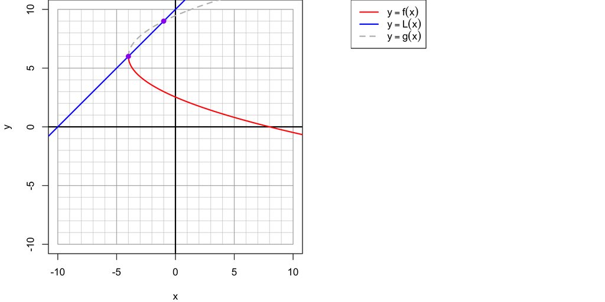

Notice, another transformed square-root function, $g(x)$, is also graphed above. It represents the other half of the parabola.

$$g(x)=-a\sqrt{n(x-h)}+k$$

Now, consider algebraically solving for values of $x_{i}$ that satisfy the equation $f(x_i)=L(x_i)$. Let $x_1$ and $x_2$ represent the two possible solutions such that $x_1<x_2$. Find both possible solutions (by inspecting the graph) and determine whether each is valid or extraneous.

- $x_1=$
- $x_1$ is solution.
- $x_2=$
- $x_2$ is solution.

Just read off the two $x$ values of the two purple points. The point further left is at point $(x_1,L(x_1))$ and the point further right is at point $(x_2,L(x_2))$. That way $x_1<x_2$, as required in the problem statement.

If the purple dot is on the red $y=f(x)$ curve, then the possible solution is a valid solution. If the purple dot is on the dashed-grey $y=g(x)$ curve, then the possible solution is extraneous. Lastly, if the purple dot is at the vertex of the parabol, then the solution is also valid.

So, in this case:

$$\begin{aligned}
x_1 &= -4 \\
x_1 &\text{ is a valid solution} \\
x_2 &= -1 \\
x_2 &\text{ is an extraneous solution}
\end{aligned}$$

A transformed square-root function, $f(x)$, and line, $L(x)$, are parameterized and graphed below.

$$f(x)=a\sqrt{n(x-h)}+k$$

$$L(x)=mx+b$$
The parameters:
$$\begin{aligned}
a &= \text{vertical flip and stretch} \\
n &= \text{horizontal flip and stretch} \\
h &= \text{horizontal translation} \\
k &= \text{vertical translation} \\
m &= \text{slope} \\
b &= \text{y-intercept}
\end{aligned}$$

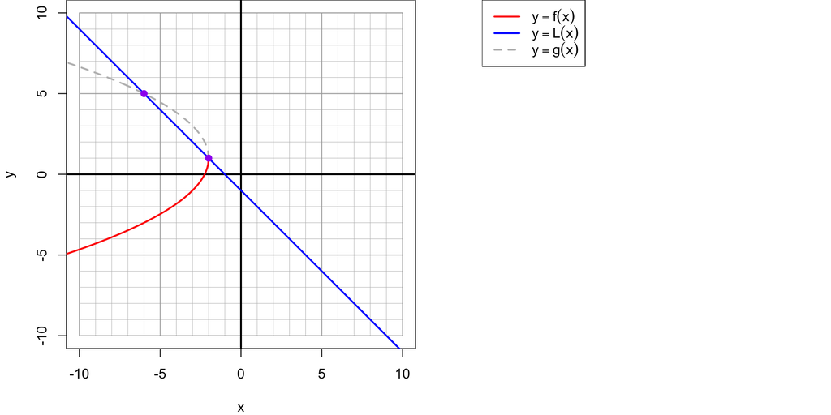

Notice, another transformed square-root function, $g(x)$, is also graphed above. It represents the other half of the parabola.

$$g(x)=-a\sqrt{n(x-h)}+k$$

Now, consider algebraically solving for values of $x_{i}$ that satisfy the equation $f(x_i)=L(x_i)$. Let $x_1$ and $x_2$ represent the two possible solutions such that $x_1<x_2$. Find both possible solutions (by inspecting the graph) and determine whether each is valid or extraneous.

- $x_1=$
- $x_1$ is solution.
- $x_2=$
- $x_2$ is solution.

Just read off the two $x$ values of the two purple points. The point further left is at point $(x_1,L(x_1))$ and the point further right is at point $(x_2,L(x_2))$. That way $x_1<x_2$, as required in the problem statement.

If the purple dot is on the red $y=f(x)$ curve, then the possible solution is a valid solution. If the purple dot is on the dashed-grey $y=g(x)$ curve, then the possible solution is extraneous. Lastly, if the purple dot is at the vertex of the parabol, then the solution is also valid.

So, in this case:

$$\begin{aligned}
x_1 &= -6 \\
x_1 &\text{ is an extraneous solution} \\
x_2 &= -2 \\
x_2 &\text{ is a valid solution}
\end{aligned}$$

A transformed square-root function, $f(x)$, and line, $L(x)$, are parameterized and graphed below.

$$f(x)=a\sqrt{n(x-h)}+k$$

$$L(x)=mx+b$$
The parameters:
$$\begin{aligned}
a &= \text{vertical flip and stretch} \\
n &= \text{horizontal flip and stretch} \\
h &= \text{horizontal translation} \\
k &= \text{vertical translation} \\
m &= \text{slope} \\
b &= \text{y-intercept}
\end{aligned}$$

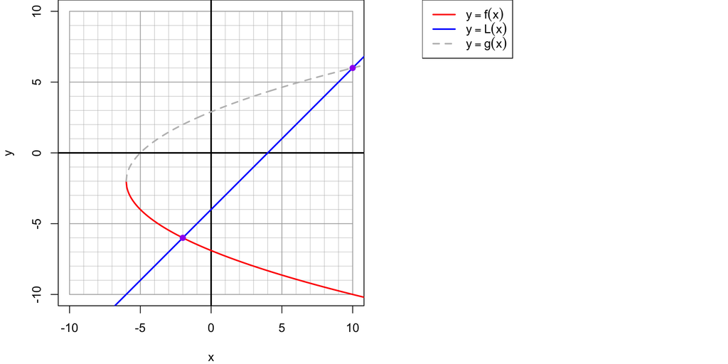

Notice, another transformed square-root function, $g(x)$, is also graphed above. It represents the other half of the parabola.

$$g(x)=-a\sqrt{n(x-h)}+k$$

Now, consider algebraically solving for values of $x_{i}$ that satisfy the equation $f(x_i)=L(x_i)$. Let $x_1$ and $x_2$ represent the two possible solutions such that $x_1<x_2$. Find both possible solutions (by inspecting the graph) and determine whether each is valid or extraneous.

- $x_1=$
- $x_1$ is solution.
- $x_2=$
- $x_2$ is solution.

Just read off the two $x$ values of the two purple points. The point further left is at point $(x_1,L(x_1))$ and the point further right is at point $(x_2,L(x_2))$. That way $x_1<x_2$, as required in the problem statement.

If the purple dot is on the red $y=f(x)$ curve, then the possible solution is a valid solution. If the purple dot is on the dashed-grey $y=g(x)$ curve, then the possible solution is extraneous. Lastly, if the purple dot is at the vertex of the parabol, then the solution is also valid.

So, in this case:

$$\begin{aligned}
x_1 &= -2 \\
x_1 &\text{ is a valid solution} \\
x_2 &= 10 \\
x_2 &\text{ is an extraneous solution}
\end{aligned}$$

A transformed square-root function, $f(x)$, and line, $L(x)$, are parameterized and graphed below.

$$f(x)=a\sqrt{n(x-h)}+k$$

$$L(x)=mx+b$$
The parameters:
$$\begin{aligned}
a &= \text{vertical flip and stretch} \\
n &= \text{horizontal flip and stretch} \\
h &= \text{horizontal translation} \\
k &= \text{vertical translation} \\
m &= \text{slope} \\
b &= \text{y-intercept}
\end{aligned}$$

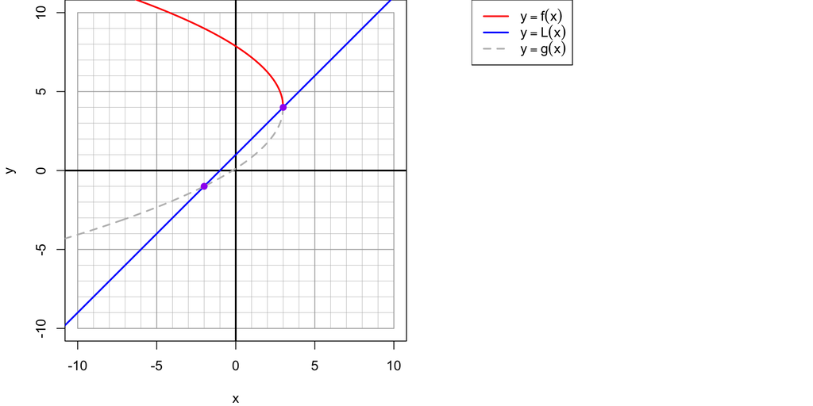

Notice, another transformed square-root function, $g(x)$, is also graphed above. It represents the other half of the parabola.

$$g(x)=-a\sqrt{n(x-h)}+k$$

Now, consider algebraically solving for values of $x_{i}$ that satisfy the equation $f(x_i)=L(x_i)$. Let $x_1$ and $x_2$ represent the two possible solutions such that $x_1<x_2$. Find both possible solutions (by inspecting the graph) and determine whether each is valid or extraneous.

- $x_1=$
- $x_1$ is solution.
- $x_2=$
- $x_2$ is solution.

Just read off the two $x$ values of the two purple points. The point further left is at point $(x_1,L(x_1))$ and the point further right is at point $(x_2,L(x_2))$. That way $x_1<x_2$, as required in the problem statement.

If the purple dot is on the red $y=f(x)$ curve, then the possible solution is a valid solution. If the purple dot is on the dashed-grey $y=g(x)$ curve, then the possible solution is extraneous. Lastly, if the purple dot is at the vertex of the parabol, then the solution is also valid.

So, in this case:

$$\begin{aligned}
x_1 &= -2 \\
x_1 &\text{ is an extraneous solution} \\
x_2 &= 3 \\
x_2 &\text{ is a valid solution}
\end{aligned}$$

A transformed square-root function, $f(x)$, and line, $L(x)$, are parameterized and graphed below.

$$f(x)=a\sqrt{n(x-h)}+k$$

$$L(x)=mx+b$$
The parameters:
$$\begin{aligned}
a &= \text{vertical flip and stretch} \\
n &= \text{horizontal flip and stretch} \\
h &= \text{horizontal translation} \\
k &= \text{vertical translation} \\
m &= \text{slope} \\
b &= \text{y-intercept}
\end{aligned}$$

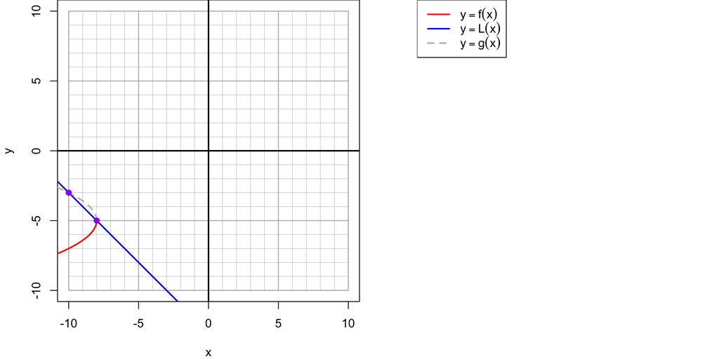

Notice, another transformed square-root function, $g(x)$, is also graphed above. It represents the other half of the parabola.

$$g(x)=-a\sqrt{n(x-h)}+k$$

Now, consider algebraically solving for values of $x_{i}$ that satisfy the equation $f(x_i)=L(x_i)$. Let $x_1$ and $x_2$ represent the two possible solutions such that $x_1<x_2$. Find both possible solutions (by inspecting the graph) and determine whether each is valid or extraneous.

- $x_1=$
- $x_1$ is solution.
- $x_2=$
- $x_2$ is solution.

Just read off the two $x$ values of the two purple points. The point further left is at point $(x_1,L(x_1))$ and the point further right is at point $(x_2,L(x_2))$. That way $x_1<x_2$, as required in the problem statement.

If the purple dot is on the red $y=f(x)$ curve, then the possible solution is a valid solution. If the purple dot is on the dashed-grey $y=g(x)$ curve, then the possible solution is extraneous. Lastly, if the purple dot is at the vertex of the parabol, then the solution is also valid.

So, in this case:

$$\begin{aligned}
x_1 &= -10 \\
x_1 &\text{ is an extraneous solution} \\
x_2 &= -8 \\
x_2 &\text{ is a valid solution}
\end{aligned}$$

A transformed square-root function, $f(x)$, and line, $L(x)$, are parameterized and graphed below.

$$f(x)=a\sqrt{n(x-h)}+k$$

$$L(x)=mx+b$$
The parameters:
$$\begin{aligned}
a &= \text{vertical flip and stretch} \\
n &= \text{horizontal flip and stretch} \\
h &= \text{horizontal translation} \\
k &= \text{vertical translation} \\
m &= \text{slope} \\
b &= \text{y-intercept}
\end{aligned}$$

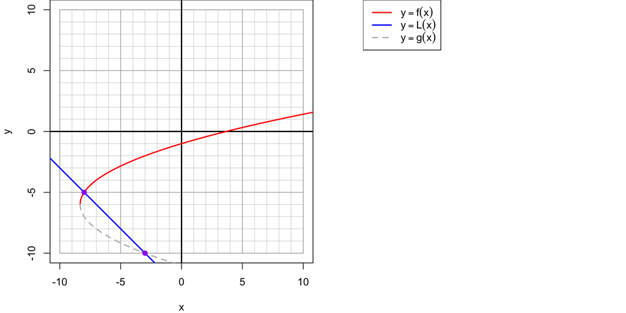

Notice, another transformed square-root function, $g(x)$, is also graphed above. It represents the other half of the parabola.

$$g(x)=-a\sqrt{n(x-h)}+k$$

Now, consider algebraically solving for values of $x_{i}$ that satisfy the equation $f(x_i)=L(x_i)$. Let $x_1$ and $x_2$ represent the two possible solutions such that $x_1<x_2$. Find both possible solutions (by inspecting the graph) and determine whether each is valid or extraneous.

- $x_1=$
- $x_1$ is solution.
- $x_2=$
- $x_2$ is solution.

Just read off the two $x$ values of the two purple points. The point further left is at point $(x_1,L(x_1))$ and the point further right is at point $(x_2,L(x_2))$. That way $x_1<x_2$, as required in the problem statement.

If the purple dot is on the red $y=f(x)$ curve, then the possible solution is a valid solution. If the purple dot is on the dashed-grey $y=g(x)$ curve, then the possible solution is extraneous. Lastly, if the purple dot is at the vertex of the parabol, then the solution is also valid.

So, in this case:

$$\begin{aligned}
x_1 &= -8 \\
x_1 &\text{ is a valid solution} \\
x_2 &= -3 \\
x_2 &\text{ is an extraneous solution}
\end{aligned}$$